# LEA tutorial - SSMPG2022

Olivier Francois and Clement Gain

09/09/2022

## Introduction

LEA is an R package dedicated to landscape population genomics and genotype-environment association (GEA) tests. LEA performs analyses of population structure (`snmf`) including imputation of missing genotypes, genome-wide tests for local adaptation (`lfmm2`), and computes measures of genetic offset based on new or predicted environments (`genetic.gap`). The R package was described in (Frichot and Francois 2015; Gain and francois 2021).

To start analyzing population genomic data with LEA, load the latest version of the package (development version 3.9.4 in this document).

```r
# To install LEA, remove the comment character in the next command line
# devtools::install_github("bcm-uga/LEA")
library(LEA)
```

This tutorial uses a simulated data set to illustrate the main functions of LEA, including a brief analysis of population structure, a GEA analysis using four environmental variables, and the computation of genetic offset for some projections of those variables.

## Example data set and population struture analysis

The data set contains a genotypic matrix stored in an lfmm format with 200 diploid individuals (rows) genotyped at 510 SNPs (columns), a matrix with 4 correlated environmental variables (env) measured for each individual. The data were simulated according to a spatially-explicit evolutionary scenario implemented in the individual-based simulation program SLIM 3 (Haller and Messer 2019). The complex demographic scenario included colonization of the species range from a single origin, and adaptation to encountered environmental conditions. To simulate natural selection, adaptive traits were controlled by a polygenic architecture, with additive effects from two (unobserved) environmental variables. From the simulation, we known that about $30\%$ of loci were under the influence of the environment.

```r
data("offset_example")
# genotypes for 200 individuals
Y <- offset_example$geno

# Four environmental variables for 200 individuals
X <- offset_example$env
```

Population structure can be analyzed with PCA and with `snmf()` that produces results similar to the popular program `structure` but that is much faster. The screeplot of the PCA suggests that there are three main genetic groups.

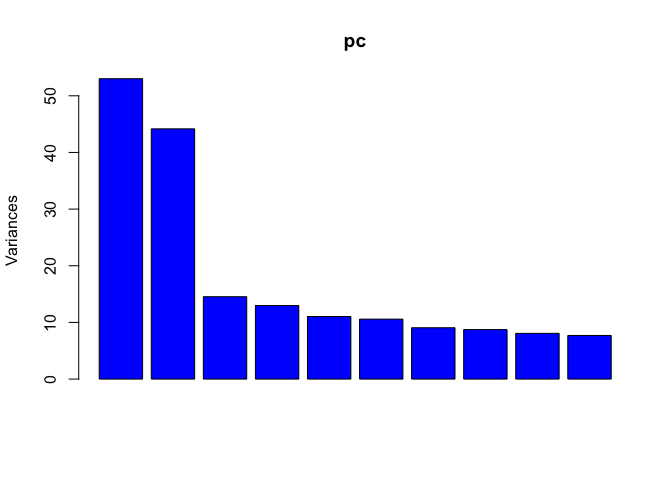

```r
pc <- prcomp(Y)
plot(pc, col = "blue")
```

The screeplot of the PCA of the environmental data also suggests that there are three main types of environmental conditions.

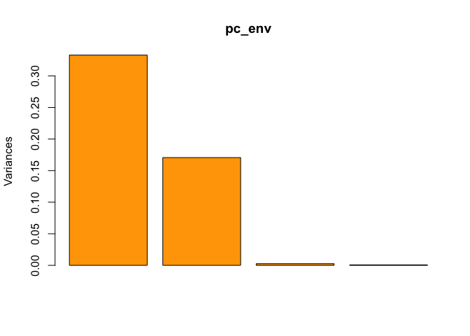

```r
pc_env <- prcomp(X)
plot(pc_env, col = "orange")
```

The next figure shows individual samples projected along the first axes of the genetic matrix, colored by similarity in environmental conditions.

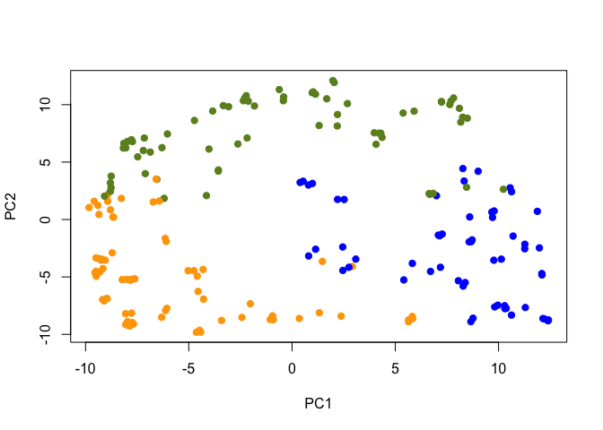

```r
cl <- kmeans(X, centers = 3)$cluster
my_colors <- c("orange", "blue", "olivedrab")
plot(pc$x, pch = 19, col = my_colors[cl])
```

The details of the `snmf()` method were described in (Frichot et al. 2014). It is similar to structure.

The method suggests four (and more) clusters, which is consistent with the isolation-by-distance model for the simulated data.

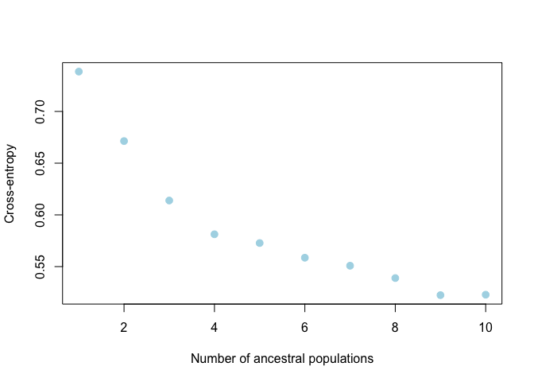

```r
# plot cross-entropy criterion of all runs of the project
plot(proj_snmf, cex = 1.2, col = "lightblue", pch = 19)
```

The barchart function can be used to display the barplot of the Q-matrix (ancestry coefficients).

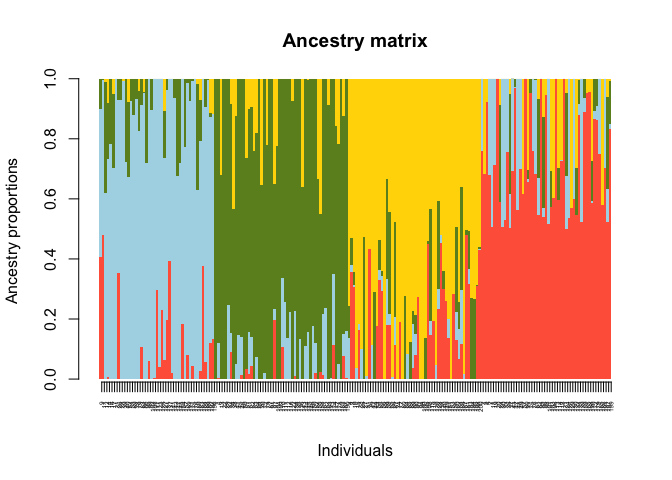

```r
# display the Q-matrix

my.colors <- c("tomato", "lightblue",
              "olivedrab", "gold")

barchart(proj_snmf, K = 4,
        border = NA, space = 0, col = my.colors,
        xlab = "Individuals", ylab = "Ancestry proportions",
        main = "Ancestry matrix") -> bp

axis(1, at = 1:length(bp$order),
    labels = bp$order, las = 3, cex.axis = .4)
```

```r
###
```

## Genotype-Environment Association (GEA) studies with LFMM

The GEA study is based on a latent factor mixed model (LFMM), a multivariate regression model that estimates the effects of environmental variables and unobserved confounders called *latent factors*. Considering a mixed model means that there are fixed and latent effects in the model (Frichot et al. 2013; Caye et al. 2019).

The reason for using LFMMs is that *neutral population structure* is widely recognized as acting as a confounder when estimating the effect of natural selection due to environmental pressures. Evaluating neutral population structure from population genomic data is, however, extremely difficult, as it requires having identified which locus is neutral and which is under selection.

LFMM is a technique that avoids the circularity issue by estimating effects of environmental variables and latent factors simultaneously. The latent factors are computed both from the genomes and from their environmnent. They are not representing neutral population structure. Instead, they can be interpreted as the best estimates of the confounding effects of neutral population structure, leading to environmental effect size estimates with minimal bias.

The analysis of population structure suggests that $K = 3$ factors could be a reasonable guess for the number of factors in LFMM.

```r
mod_lfmm2 <- lfmm2(input = Y,
                   env = X,
                   K = 3)
```

Once the LFMM is adjusted to the genomic data, the GEA significance values can be obtained from standard Student (`full = FALSE`) and Fischer (`full = TRUE`) tests. Here `full` means that all environmental variables are used in the test.

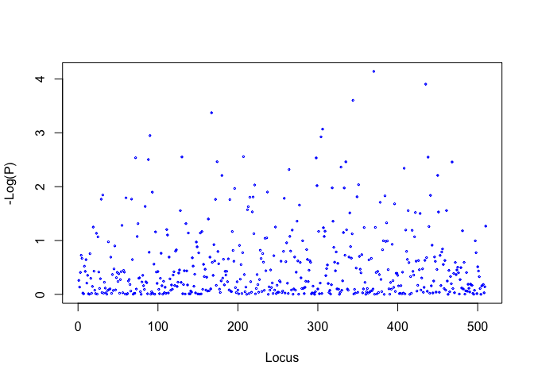

```r
pv_lfmm2 = lfmm2.test(object = mod_lfmm2,
                      input = Y,
                      env = X,
                      full = TRUE)$pvalues

plot(-log10(pv_lfmm2 ), cex = .3, xlab = "Locus",  ylab = "-Log(P)", col = "blue")
```

To make a decision about which loci have significant levels of association, the FDR control algorithm can be used. Here, an unusually high level ($q = 20\%$) is justified because the list of candidate loci obtained after the multiple testing procedure (red circles) is very short. The orange line corresponds to the Bonferroni threshold for a type I error of $10\%$.

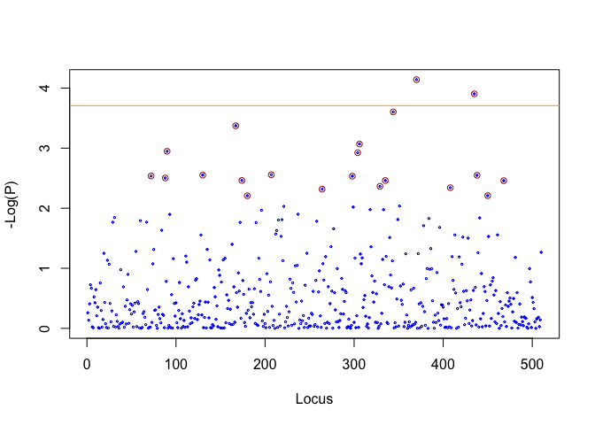

```r
qv_lfmm2  <- qvalue::qvalue(pv_lfmm2, fdr.level = 0.2)

plot(-log10(pv_lfmm2 ), cex = .3, xlab = "Locus",  ylab = "-Log(P)", col = "blue")
# Orange line: Bonferonni multiple testing threshold for significance
abline(h = -log10(0.1/ncol(Y)), col = "orange")

candidates <- which(qv_lfmm2$significant)

# Circles: Candidate loci at FDR level = 30%
points(candidates, -log10(pv_lfmm2)[candidates], cex = .9, col = "brown")
```

The candidate list contains 21 loci. Knowing the truth about which locus is under selection makes the result a bit disappointing. The list contains 3 errors which means that the observed FDR is $3/21 = 14.3\%$, not too far from the targeted value ($4/21$). However, power is very low (around $10\%$), showing that most loci influenced by environmental selection remained undetected in the GEA study.

## Genomic offset: A new measure in LEA

Several approaches incorporate genomic information on local adaptation into predictive measures of population maladaptation across ecological changes (Fitzpatrick et al. 2015, Waldvogel et al. 2020, Capblancq et al 2020). Those predictive measures, called genomic offset, first estimate a statistical relationship between environmental gradients and allelic frequencies using genotype-environment association (GEA) models. The inferred relationship is then used to evaluate differences in predicted allele frequencies at pairs of points in the ecological niche.

We developed a geometrical framework for genomic offset, argueing that the measures which have primarily been defined as distances in genetic space (distance between allele frequencies), can be alternatively viewed as distances in environmental space. Considering the duality between genetic space and environmental space, our approach links measures of genomic offset to the geometry of the ecological niche, and is implemented in the function `genetic.gap`.

The genetic gap is based on the estimates of environmental effect sizes obtained from an LFMM. The relationship inferred in the GEA is then used to fit and predict allelic variation at all genomic loci, alleviating the need for a set of candidate loci and the choice of a significance level.

For two environmental vectors ${\bf x}$ and ${\bf y}$ in $d$-dimensional space ($d = 4$, the number of variables), a scalar product is defined as
$$\langle {\bf x} , {\bf y}\rangle_{\bf b} = {\bf x} {\bf C}_{\bf b} {\bf y}^T$$
where ${\bf C}_{\bf b} = \mathbb{E}[{\bf b} {\bf b}^T]$ is the $d \times d$ covariance matrix of effect sizes and the mathematical notation $\mathbb{E}[.]$ stands for an average over all genomic loci included in the analysis. The genetic gap is computed as follows

$$G^2({\bf x} , {\bf y}) = ({\bf x - y}) {\bf C}_{\bf b} ({\bf x - y})^T ,$$
or equivalently as
$$G^2({\bf x} , {\bf y}) = \mathbb{E}[ ({\bf x} {\bf b}^T - {\bf y} {\bf b}^T )^2 ] .$$

The above equations show the duality of the definition of the genetic gap, which can be considered either as a (squared) environmental distance in the first equation, or as a (squared) distance between predicted allele frequencies in the second equation.

By analogy with a single random mating population sampled through time, the genetic gap corresponds to the definition of the tree statistic, $F_2(f({\bf x}); f({\bf y}))$, which measures the length of the tree branch separating local populations sampled at the two points (Peter 2016). The genetic gap also corresponds to the average value of Nei’s statistic $\mathbb{E}[D_{\rm ST}]/2$, which evaluates the genetic diversity between populations at which ${\bf x}$ and ${\bf y}$ are observed (Nei, 1973).

With adaptation to environmental conditions, interpretations can be more complex than with neutrally evolving populations. For a population for which an abrupt environmental change occurred, the genetic gap corresponds to the difference in the variance of allele frequencies across the genome
$$G^2({\bf x} , {\bf x}_t) = \mathbb{V}{\rm ar}(f({\bf x}_t)) - \mathbb{V}{\rm ar}(f({\bf x}))$$
when the change ${\bf x}_t - {\bf x}$ is orthogonal to the current conditions, ${\bf x}$. In this case, the above difference can be interpreted in terms of loss of population size (or loss of survival probability) at the sampled location.

To test this hypothesis, an instantaneous change in environmental conditions was applied at the end of the simulation, and the loss in survival probability was measured at each sampled location. The new conditions are loaded as follows.

```r
X_pred <- offset_example$env.pred
```

The genetic gap can be computed at each sampled location, or at new locations (not shown).

```r
g_gap <- genetic.gap(input = Y,
                     env = X,
                     pred.env = X_pred,
                     K = 3)
```

Now, we can plot the squared root of the genetic gap vs the Euclidean environmental distance to see that these distances are correlated.

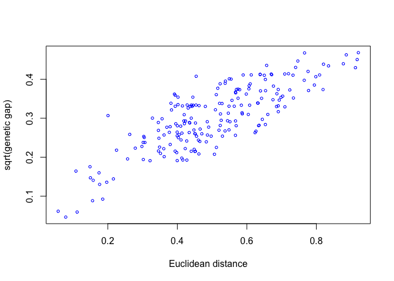

```r
# plot the squared root of the genetic gap vs Euclidean environmental distance
Delta = X - X_pred
dist_env = sqrt( rowSums(Delta^2) )
plot(dist_env, g_gap$distance, xlab ="Euclidean distance",  ylab ="sqrt(genetic gap)", cex = .6, col = "blue")
```

The survival loss (extinction) in the simulation can then be compared to the genetic gap.

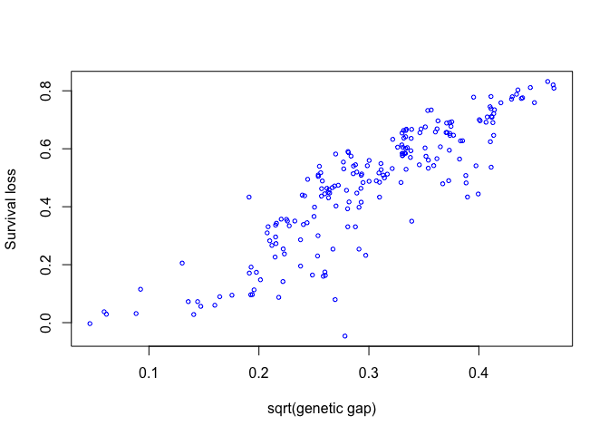

```r
survival_loss <- read.table("fitness_variation.txt", header = FALSE)[,1]

# plot the survival loss vs squared root of the genetic gap
plot(g_gap$distance, survival_loss , ylab ="Survival loss",  xlab ="sqrt(genetic gap)", cex = .6, col = "blue")
```

The correlation between the genetic gap and the survival loss is equal to

```r
cor(g_gap$distance, survival_loss)^2
```

```
## [1] 0.7674913
```

It is greater than the correlation between the environmental distance and the survival loss.

```r
cor(dist_env, survival_loss)^2
```

```
## [1] 0.5551203
```

## Genomic offset from candidate loci

The analysis can be rerun with a subset of candidate loci obtained from the GEA study.

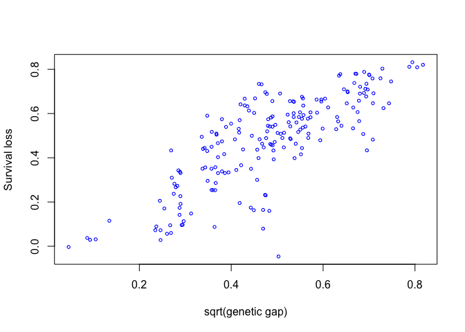

```r
g_gap_candidate <- genetic.gap(input = Y,
                               env = X,
                               pred.env = X_pred,
                               candidate.loci = candidates,
                               K = 3)


# plot the survival loss vs squared root of the genetic gap (candidate loci)

plot(g_gap_candidate$distance, survival_loss ,
     ylab ="Survival loss",
     xlab ="sqrt(genetic gap)", cex = .6, col = "blue")
```

The fit is not as good as with all loci.

```r
cor(g_gap_candidate$distance, survival_loss)^2
```

```
## [1] 0.6296889
```

## Importance of variables

Next we can evaluate the importance of the environmental variables in the analysis. For this, the environmental data should be scaled. For example, if there are temperatures measured in degree Celsius and precipitations measured in millimeters, then it is better to consider variables that are unitless. Scaling does not change genetic gaps.

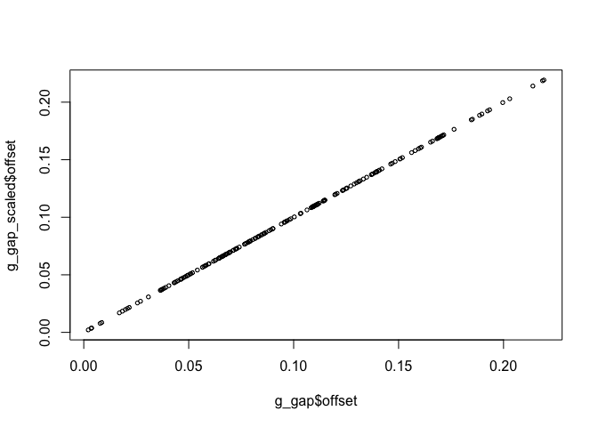

```r
g_gap_scaled <- genetic.gap(input = Y,
                           env = X,
                           pred.env = X_pred,
                           scale = TRUE,
                           K = 3)

# Scaling does not change genetic gaps
plot(g_gap$offset, g_gap_scaled$offset,  cex = .6)
```

But scaling can be useful for evaluating the relative importance of environmental variables. Here only two dimensions of the environmental space influence the genetic gap.

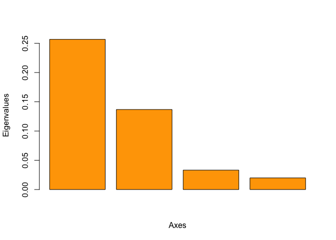

```r
barplot(g_gap_scaled$eigenvalues, col = "orange", xlab = "Axes", ylab = "Eigenvalues")
```

```r
g_gap_scaled$vectors[,1:2]
```

```
##             [,1]         [,2]
## [1,]  0.69833248  0.488023116
## [2,] -0.45883291  0.780847754
## [3,] -0.54664485  0.006994408
## [4,] -0.05462159 -0.389950384
```

## References

- Capblancq, T., Fitzpatrick, M. C., Bay, R. A., Exposito-Alonso, M., Keller, S. R. (2020). Genomic prediction of (mal)adaptation across current and future climatic landscapes. Annual Review of Ecology, Evolution, and Systematics, 51, 245-269.
- Caye, K., Jumentier, B., Lepeule, J., Franois, O. (2019). LFMM 2: fast and accurate inference of gene-environment associations in genome-wide studies. Molecular Biology and Evolution, 36(4), 852-860.
- Fitzpatrick, M. C., Keller, S. R. (2015). Ecological genomics meets community-level modelling of biodiversity: Mapping the genomic landscape of current and future environmental adaptation. Ecology Letters, 18(1), 1-16.
- Frichot, E., Schoville, S. D., Bouchard, G., Franois, O. (2013). Testing for associations between loci and environmental gradients using latent factor mixed models. Molecular Biology and Evolution, 30(7), 1687-1699.
- Frichot, E., Mathieu, F., Trouillon, T., Bouchard, G., Franois, O. (2014). Fast and efficient estimation of individual ancestry coefficients. Genetics, 196(4), 973-983.
- Frichot, E., Franois, O. (2015). LEA: An R package for landscape and ecological association studies. Methods in Ecology and Evolution, 6(8), 925-929.
- Gain, C., Franois, O. (2021). LEA 3: Factor models in population genetics and ecological genomics with R. Molecular Ecology Resources, 21(8), 2738-2748.
- Haller, B., Messer, P.W. (2019). SLiM 3: Forward Genetic Simulations Beyond the Wright–Fisher Model. Molecular Biology and Evolution, 36(3), 632-637.
- Nei, M. (1973). Analysis of gene diversity in subdivided populations. Proc. Natl. Acad. Sci. USA, 70, 3321-23.
- Peter, B. M. (2016). Admixture, population structure, and F-statistics. Genetics, 202(4), 1485-1501.
- Waldvogel, A. M., Feldmeyer, B., Rolshausen, G., Exposito-Alonso, M., Rellstab, C., Kofler, R., {} (2020). Evolutionary genomics can improve prediction of species’ responses to climate change. Evolution Letters, 4(1), 4-18.